# CIND 123: Data Analytics Basic Methods: Assignment-3_W2022

# Assignment 3 (10%)

## Total 100 Marks

### CIND123 DK0 Student Number:500778806

## Instructions

Use RStudio for this assignment. Complete the assignment by inserting your R code wherever you see the string “#INSERT YOUR ANSWER HERE”.

Submit **both** the rmd and generated output files. Failing to submit both files will be subject to mark deduction.

## Sample Question and Solution

Use `seq()` to create the vector $(2,4,6,\ldots,20)$.

```r
#INSERT YOUR ANSWER HERE.
seq(2,20,by = 2)
```

```
##  [1]  2  4  6  8 10 12 14 16 18 20
```

## Question 1 [15 Pts]

1. [5 Pts] First and second midterm grades of some students are given as c(85,76,78,88,90,95,42,31) and c(55,76,48,58,80,75,32,22). Set R variables `first` and `second` respectively. Then find the least-squares line relating the second midterm to the first midterm.

   Does the assumption of a linear relationship appear to be reasonable in this case? Give reasons to your answer as a comment.

```r
#INSERT YOUR ANSWER HERE
first <- c(85,76,78,88,90,95,42,31)
second <- c(55,76,48,58,80,75,32,22)

relation_model <- lm(second ~ first)
summary(relation_model)
```

```
##
## Call:
## lm(formula = second ~ first)
##
## Residuals:
##      Min       1Q   Median       3Q      Max
## -11.5445  -9.4942  -0.2429   4.4465  18.0122
##
## Coefficients:
##             Estimate Std. Error t value Pr(>|t|)
## (Intercept)  -1.1669    13.8930  -0.084  0.93579
## first         0.7784     0.1819   4.280  0.00521 **
## ---
## Signif. codes:  0 '***' 0.001 '**' 0.01 '*' 0.05 '.' 0.1 ' ' 1
##
## Residual standard error: 11.36 on 6 degrees of freedom
## Multiple R-squared:  0.7532, Adjusted R-squared:  0.7121
## F-statistic: 18.31 on 1 and 6 DF,  p-value: 0.005208
```

```r
# The relation appears to be linear in this case as the median is close to 0 and the coefficient of determination R-squared is close to +1.
```

2. [5 Pts] Plot the second midterm as a function of the first midterm using a scatterplot and graph the least-square line on the same plot.

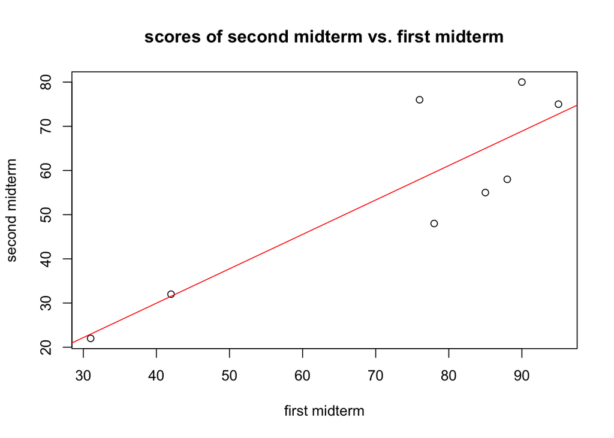

```r
#INSERT YOUR ANSWER HERE

# Using the intercept and slope of the linear model
plot(first, second, pch=1,
xlab="first midterm",
ylab="second midterm",
main="scores of second midterm vs. first midterm")
abline(-1.1669, 0.7784, col="red")
```

3. [5 Pts] Use the regression line to predict the second midterm grade when the first midterm grade is 88.

```r
#INSERT YOUR ANSWER HERE

# Using the coefficients from the linear model
predict_grade <- -1.1669 + 0.7784  * 88
predict_grade
```

```
## [1] 67.3323
```